# **BLINKIT ANALYSIS USING PYTHON**

### **Importing Libraries**

```python
import pandas as pd
import numpy as np
import matplotlib.pyplot as plt
import seaborn as sns
import warnings
import plotly.express as px

# Consistency in plotting
sns.set_style('whitegrid')
plt.rcParams['figure.figsize'] = (10, 6)
sns.set_palette('viridis')

# For cleaner output
warnings.filterwarnings('ignore')

print("All packages imported successfully!")
print(f"Pandas: {pd.__version__}, Numpy: {np.__version__}, Seaborn: {sns.__version__}")
```

```
All packages imported successfully!
Pandas: 2.3.2, Numpy: 2.3.3, Seaborn: 0.13.2
```

### **Importing Raw Data**

```python
df = pd.read_csv("F:/Projects/Python_projects/blinkit_data.csv") #loading the data
print("Data imported successfully")
```

```
Data imported successfully
```

### **Sample Data**

```python
df.head(20)
```

|  | Item Fat Content | Item Identifier | Item Type | Outlet Establishment Year | Outlet Identifier | Outlet Location Type | Outlet Size | Outlet Type | Item Visibility | Item Weight | Sales | Rating |
| --- | --- | --- | --- | --- | --- | --- | --- | --- | --- | --- | --- | --- |
| 0 | Regular | FDX32 | Fruits and Vegetables | 2012 | OUT049 | Tier 1 | Medium | Supermarket Type1 | 0.100014 | 15.10 | 145.4786 | 5.0 |
| 1 | Low Fat | NCB42 | Health and Hygiene | 2022 | OUT018 | Tier 3 | Medium | Supermarket Type2 | 0.008596 | 11.80 | 115.3492 | 5.0 |
| 2 | Regular | FDR28 | Frozen Foods | 2010 | OUT046 | Tier 1 | Small | Supermarket Type1 | 0.025896 | 13.85 | 165.0210 | 5.0 |
| 3 | Regular | FDL50 | Canned | 2000 | OUT013 | Tier 3 | High | Supermarket Type1 | 0.042278 | 12.15 | 126.5046 | 5.0 |
| 4 | Low Fat | DRI25 | Soft Drinks | 2015 | OUT045 | Tier 2 | Small | Supermarket Type1 | 0.033970 | 19.60 | 55.1614 | 5.0 |
| 5 | low fat | FDS52 | Frozen Foods | 2020 | OUT017 | Tier 2 | Small | Supermarket Type1 | 0.005505 | 8.89 | 102.4016 | 5.0 |
| 6 | Low Fat | NCU05 | Health and Hygiene | 2011 | OUT010 | Tier 3 | Small | Grocery Store | 0.098312 | 11.80 | 81.4618 | 5.0 |
| 7 | Low Fat | NCD30 | Household | 2015 | OUT045 | Tier 2 | Small | Supermarket Type1 | 0.026904 | 19.70 | 96.0726 | 5.0 |
| 8 | Low Fat | FDW20 | Fruits and Vegetables | 2000 | OUT013 | Tier 3 | High | Supermarket Type1 | 0.024129 | 20.75 | 124.1730 | 5.0 |
| 9 | Low Fat | FDX25 | Canned | 1998 | OUT027 | Tier 3 | Medium | Supermarket Type3 | 0.101562 | NaN | 181.9292 | 5.0 |
| 10 | LF | FDX21 | Snack Foods | 1998 | OUT027 | Tier 3 | Medium | Supermarket Type3 | 0.084555 | NaN | 109.8912 | 5.0 |
| 11 | Low Fat | NCU41 | Health and Hygiene | 2017 | OUT035 | Tier 2 | Small | Supermarket Type1 | 0.052045 | 18.85 | 192.1846 | 5.0 |
| 12 | Low Fat | FDL20 | Fruits and Vegetables | 2022 | OUT018 | Tier 3 | Medium | Supermarket Type2 | 0.128938 | 17.10 | 112.3886 | 5.0 |
| 13 | Low Fat | NCR54 | Household | 2000 | OUT013 | Tier 3 | High | Supermarket Type1 | 0.090487 | 16.35 | 195.2110 | 5.0 |
| 14 | Low Fat | FDH19 | Meat | 1998 | OUT027 | Tier 3 | Medium | Supermarket Type3 | 0.032928 | NaN | 173.1738 | 5.0 |
| 15 | Regular | FDB57 | Fruits and Vegetables | 2017 | OUT035 | Tier 2 | Small | Supermarket Type1 | 0.018802 | 20.25 | 222.1772 | 5.0 |
| 16 | Low Fat | FDO23 | Breads | 2022 | OUT018 | Tier 3 | Medium | Supermarket Type2 | 0.147024 | 17.85 | 93.7436 | 5.0 |
| 17 | Low Fat | NCB07 | Household | 2012 | OUT049 | Tier 1 | Medium | Supermarket Type1 | 0.077628 | 19.20 | 197.6110 | 5.0 |
| 18 | Low Fat | FDJ56 | Fruits and Vegetables | 1998 | OUT027 | Tier 3 | Medium | Supermarket Type3 | 0.182515 | NaN | 98.7700 | 5.0 |
| 19 | Low Fat | DRN47 | Hard Drinks | 2022 | OUT018 | Tier 3 | Medium | Supermarket Type2 | 0.016895 | 12.10 | 178.5660 | 5.0 |

```python
df.tail(10)
```

|  | Item Fat Content | Item Identifier | Item Type | Outlet Establishment Year | Outlet Identifier | Outlet Location Type | Outlet Size | Outlet Type | Item Visibility | Item Weight | Sales | Rating |
| --- | --- | --- | --- | --- | --- | --- | --- | --- | --- | --- | --- | --- |
| 8513 | Regular | DRY23 | Soft Drinks | 1998 | OUT027 | Tier 3 | Medium | Supermarket Type3 | 0.108568 | NaN | 42.9112 | 4.0 |
| 8514 | low fat | FDA11 | Baking Goods | 1998 | OUT027 | Tier 3 | Medium | Supermarket Type3 | 0.043029 | NaN | 94.7436 | 4.0 |
| 8515 | low fat | FDK38 | Canned | 1998 | OUT027 | Tier 3 | Medium | Supermarket Type3 | 0.053032 | NaN | 149.1734 | 4.0 |
| 8516 | low fat | FDO38 | Canned | 1998 | OUT027 | Tier 3 | Medium | Supermarket Type3 | 0.072486 | NaN | 78.9986 | 4.0 |
| 8517 | low fat | FDG32 | Fruits and Vegetables | 1998 | OUT027 | Tier 3 | Medium | Supermarket Type3 | 0.175143 | NaN | 222.3772 | 4.0 |
| 8518 | low fat | NCT53 | Health and Hygiene | 1998 | OUT027 | Tier 3 | Medium | Supermarket Type3 | 0.000000 | NaN | 164.5526 | 4.0 |
| 8519 | low fat | FDN09 | Snack Foods | 1998 | OUT027 | Tier 3 | Medium | Supermarket Type3 | 0.034706 | NaN | 241.6828 | 4.0 |
| 8520 | low fat | DRE13 | Soft Drinks | 1998 | OUT027 | Tier 3 | Medium | Supermarket Type3 | 0.027571 | NaN | 86.6198 | 4.0 |
| 8521 | reg | FDT50 | Dairy | 1998 | OUT027 | Tier 3 | Medium | Supermarket Type3 | 0.107715 | NaN | 97.8752 | 4.0 |
| 8522 | reg | FDM58 | Snack Foods | 1998 | OUT027 | Tier 3 | Medium | Supermarket Type3 | 0.000000 | NaN | 112.2544 | 4.0 |

### **Data Cleaning & Initial Exploration**

```python
print("Rows and Columns:", df.shape)
print("Columns:", df.columns.tolist()) #Overview of shape and columns
```

```
Rows and Columns: (8523, 12)
Columns: ['Item Fat Content', 'Item Identifier', 'Item Type', 'Outlet Establishment Year', 'Outlet Identifier', 'Outlet Location Type', 'Outlet Size', 'Outlet Type', 'Item Visibility', 'Item Weight', 'Sales', 'Rating']
```

```python
print("Data Types:\n", df.dtypes) #viewing data types
```

```
Data Types:
 Item Fat Content              object
Item Identifier               object
Item Type                     object
Outlet Establishment Year      int64
Outlet Identifier             object
Outlet Location Type          object
Outlet Size                   object
Outlet Type                   object
Item Visibility              float64
Item Weight                  float64
Sales                        float64
Rating                       float64
dtype: object
```

```python
print("Missing Values:\n", df.isnull().sum())  #checking missing values
```

```
Missing Values:
 Item Fat Content                0
Item Identifier                 0
Item Type                       0
Outlet Establishment Year       0
Outlet Identifier               0
Outlet Location Type            0
Outlet Size                     0
Outlet Type                     0
Item Visibility                 0
Item Weight                  1463
Sales                           0
Rating                          0
dtype: int64
```

```python
print(df['Item Fat Content'].unique())
```

```
['Regular' 'Low Fat' 'low fat' 'LF' 'reg']
```

```python
df['Item Fat Content'] = df['Item Fat Content'].replace({'LF':'Low Fat',
                                                         'low fat':'Low Fat',
                                                         'reg':'Regular'})
print("Item Fat Content updated")
print(df['Item Fat Content'].unique())
```

```
Item Fat Content updated
['Regular' 'Low Fat']
```

```python
df['Item Weight'] = df['Item Weight'].fillna(df['Item Weight'].median()) #replacing missing weights with median weight
print("Missing values replaced")

df['Item Visibility'] = df['Item Visibility'].replace(0, np.nan)
df['Item Visibility'] = df['Item Visibility'].fillna(df['Item Visibility'].median())
print((df['Item Visibility'] == 0).sum(), "zeros left")
print(df['Item Visibility'].isnull().sum(), "NaNs left")

print("Zero values fixed")
```

```
Missing values replaced
0 zeros left
0 NaNs left
Zero values fixed
```

```python
df.describe()  #quick stats
```

|  | Outlet Establishment Year | Item Visibility | Item Weight | Sales | Rating |
| --- | --- | --- | --- | --- | --- |
| count | 8523.000000 | 8523.000000 | 8523.00000 | 8523.000000 | 8523.000000 |
| mean | 2010.831867 | 0.069699 | 12.81342 | 140.992782 | 3.965857 |
| std | 8.371760 | 0.048826 | 4.22724 | 62.275067 | 0.605651 |
| min | 1998.000000 | 0.003575 | 4.55500 | 31.290000 | 1.000000 |
| 25% | 2000.000000 | 0.033085 | 9.31000 | 93.826500 | 4.000000 |
| 50% | 2012.000000 | 0.057792 | 12.60000 | 143.012800 | 4.000000 |
| 75% | 2017.000000 | 0.094585 | 16.00000 | 185.643700 | 4.200000 |
| max | 2022.000000 | 0.328391 | 21.35000 | 266.888400 | 5.000000 |

### **Quick Analysis**

• Oldest store was established in 1998, while the newest opened in 2022. • Most stores were established after 2000, with half of them after 2012. • Average item visibility is about 6.9%. • Item weights range from 4.5 kg to 21.3 kg, with an average of 12.81 kg. • Most items are rated 4 out of 5. • Sales range from $31.29 (lowest) to $266.88 (highest).

### **Univariate Analysis**

#### **A. Numerical Variables**

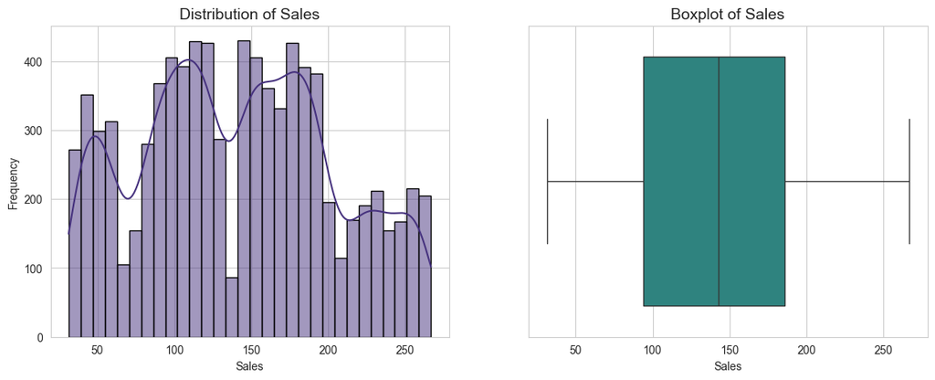

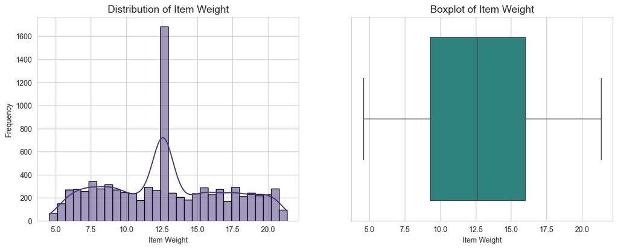

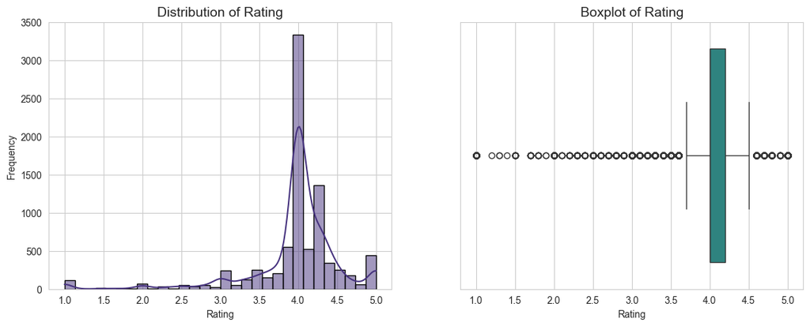

```python
def univariate_numeric(col):
    plt.figure(figsize=(14,5))

    # Histogram + KDE
    plt.subplot(1,2,1)
    sns.histplot(df[col], bins=30, kde=True, palette="viridis", edgecolor="black")
    plt.title(f"Distribution of {col}", fontsize=14)
    plt.xlabel(col)
    plt.ylabel("Frequency")

    # Boxplot
    plt.subplot(1,2,2)
    sns.boxplot(x=df[col], palette="viridis")
    plt.title(f"Boxplot of {col}", fontsize=14)
    plt.xlabel(col)

    plt.show()

univariate_numeric("Sales")
univariate_numeric("Item Weight")
univariate_numeric("Rating")
```

#### **B. Categorical Variables**

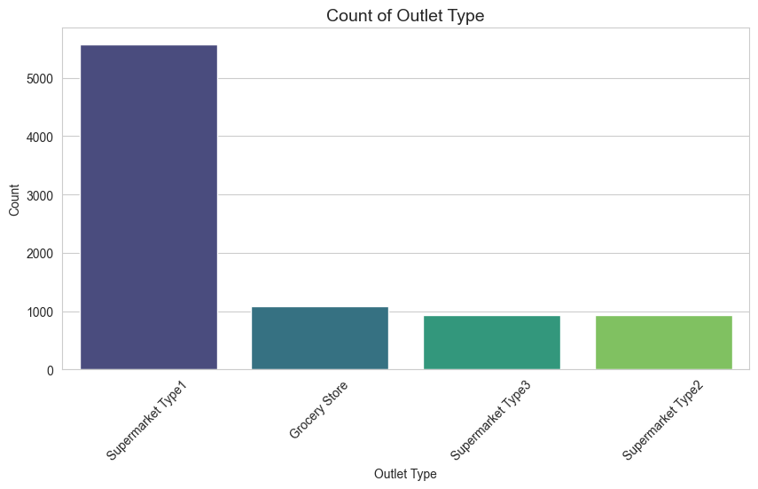

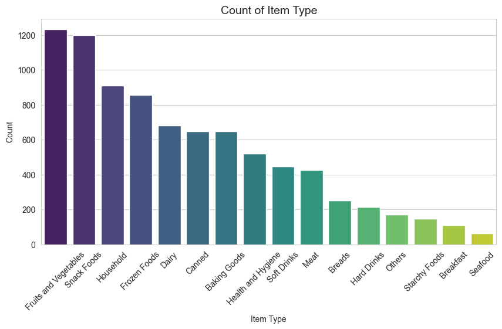

```python
def univariate_categorical(col):
    plt.figure(figsize=(10,5))
    sns.countplot(x=df[col], palette="viridis", order=df[col].value_counts().index)
    plt.title(f"Count of {col}", fontsize=14)
    plt.xlabel(col)
    plt.ylabel("Count")
    plt.xticks(rotation=45)
    plt.show()

univariate_categorical("Outlet Type")
univariate_categorical("Item Type")
```

### **Business requirements**

#### **KPI's Requirement**

```python
#Total Sales
total_sales = df['Sales'].sum()

#Average Sales
average_sales = df['Sales'].mean()

#No. of Items Sold
no_of_items_sold = df['Sales'].count()

#Average Ratings
average_ratings = df['Rating'].mean()


print(f"Total Sales: ${total_sales:,.0f}")
print(f"Average Sales: ${average_sales:,.1f}")
print(f"No. of Items Sold: {no_of_items_sold:,.0f}")
print(f"Average Ratings: {average_ratings:,.1f}")
```

```
Total Sales: $1,201,681
Average Sales: $141.0
No. of Items Sold: 8,523
Average Ratings: 4.0
```

### **Charts requirements**

#### **A. Total Sales by Fat Content**

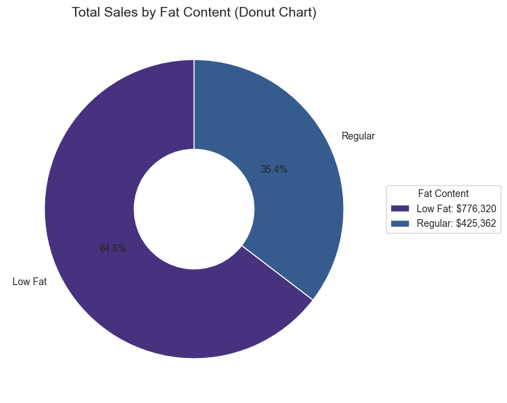

```python
sales_by_fat = df.groupby('Item Fat Content')['Sales'].sum()

plt.figure(figsize=(7,7))
wedges, texts, autotexts = plt.pie(
    sales_by_fat,
    labels=sales_by_fat.index,
    autopct='%1.1f%%',
    startangle=90,
    wedgeprops=dict(width=0.6, edgecolor='w')
)

labels_with_sales = [f"{label}: ${value:,.0f}"
                     for label, value in zip(sales_by_fat.index, sales_by_fat)]
plt.legend(wedges, labels_with_sales, title="Fat Content",
           loc="center left", bbox_to_anchor=(1, 0, 0.5, 1))

plt.title("Total Sales by Fat Content (Donut Chart)", fontsize=14)
plt.show()
```

#### **B. Total Sales by Item Type**

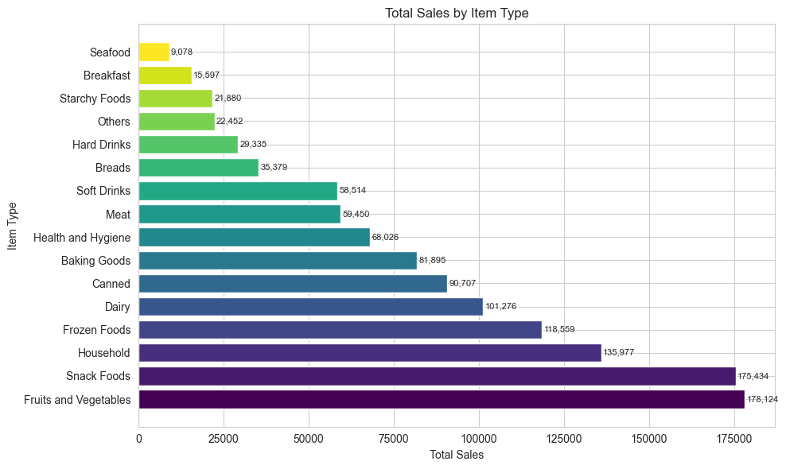

```python
sales_by_type = df.groupby('Item Type')['Sales'].sum().sort_values(ascending=False) #group by sales and sort descending

plt.figure(figsize=(10, 6))
bars = plt.barh(sales_by_type.index, sales_by_type.values, color=plt.cm.viridis(np.linspace(0,1,len(sales_by_type))))

plt.xlabel('Total Sales')
plt.ylabel('Item Type')
plt.title('Total Sales by Item Type')

# Add labels on bars
for bar in bars:
    plt.text(bar.get_width() + 500,   # offset a little to the right
             bar.get_y() + bar.get_height()/2,
             f'{bar.get_width():,.0f}',
             va='center', fontsize=8)

plt.tight_layout()
plt.show()
```

#### **C. Fat Content by Outlet for Total Sales**

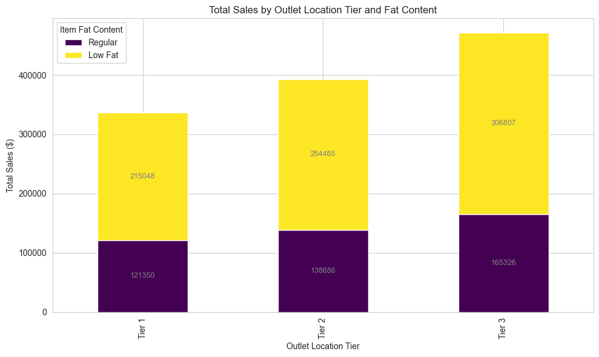

```python
grouped = df.groupby(['Outlet Location Type','Item Fat Content'])['Sales'].sum().unstack() #groupby outlet location type & fat content
grouped = grouped[['Regular','Low Fat']]  #ensure order

ax = grouped.plot(
    kind='bar',
    stacked=True,
    figsize=(10,6),
    colormap='viridis',
    title='Total Sales by Outlet Location Tier and Fat Content'
)  #plotting stacked bar chart

plt.xlabel('Outlet Location Tier')
plt.ylabel('Total Sales ($)')
plt.legend(title='Item Fat Content')

for container in ax.containers:
    ax.bar_label(container, fmt='%.0f', label_type='center', fontsize=9, color="grey")

plt.tight_layout()
plt.show()
```

#### **D. Total Sales by Outlet Establishment**

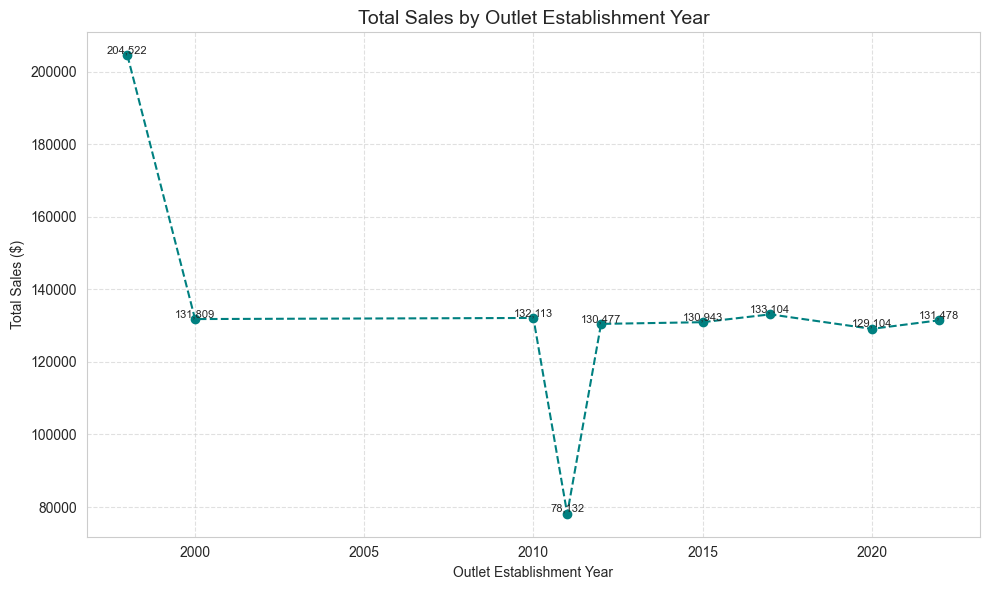

```python
sales_by_year = df.groupby('Outlet Establishment Year')['Sales'].sum().sort_index()

plt.figure(figsize=(10,6))
plt.plot(sales_by_year.index, sales_by_year.values, marker='o', linestyle='--', color="teal")

plt.xlabel('Outlet Establishment Year')
plt.ylabel('Total Sales ($)')
plt.title('Total Sales by Outlet Establishment Year', fontsize=14)
plt.grid(True, linestyle="--", alpha=0.6)

for x, y in zip(sales_by_year.index, sales_by_year.values):
    plt.text(x, y, f'{y:,.0f}', ha='center', va='bottom', fontsize=8) #adding data labels

plt.tight_layout()
plt.show()
```

#### **E. Sales by Outlet Size**

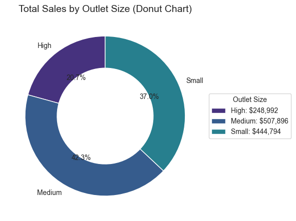

```python
sales_by_size = df.groupby('Outlet Size')['Sales'].sum()

plt.figure(figsize=(6,6))
wedges, texts, autotexts = plt.pie(
    sales_by_size,
    labels=sales_by_size.index,
    autopct='%1.1f%%',
    startangle=90,
    wedgeprops=dict(width=0.4, edgecolor='w')
)

labels_with_sales = [f"{label}: ${value:,.0f}"
                     for label, value in zip(sales_by_size.index, sales_by_size)]
plt.legend(wedges, labels_with_sales, title="Outlet Size",
           loc="center left", bbox_to_anchor=(1, 0, 0.5, 1)) #adding legends with total sale by outlet size

plt.title("Total Sales by Outlet Size (Donut Chart)", fontsize=14)
plt.tight_layout()
plt.show()
```

#### **F. Sales by Outlet Location**

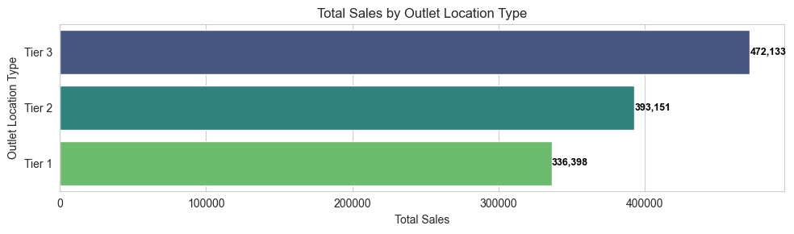

```python
sales_by_location = df.groupby('Outlet Location Type')['Sales'].sum().reset_index()
sales_by_location = sales_by_location.sort_values('Sales', ascending= False)

plt.figure(figsize=(10, 3))
ax = sns.barplot(
    x='Sales',
    y='Outlet Location Type',
    data=sales_by_location,
    palette='viridis'
)

plt.xlabel('Total Sales')
plt.ylabel('Outlet Location Type')
plt.title('Total Sales by Outlet Location Type')

for i, v in enumerate(sales_by_location['Sales']):
    ax.text(v, i, f'{v:,.0f}', color='black', va='center', fontweight='bold', fontsize=9)

plt.tight_layout()
plt.show()
```

### **Business Insights**

```python
#Top-selling item types
top_item_types = df.groupby('Item Type')['Sales'].sum().sort_values(ascending=False).head(5)
print("Top 5 selling item types:\n", top_item_types)
```

```
Top 5 selling item types:
 Item Type
Fruits and Vegetables    178124.0810
Snack Foods              175433.9204
Household                135976.5254
Frozen Foods             118558.8814
Dairy                    101276.4596
Name: Sales, dtype: float64
```

```python
# Highest sales by outlet
top_outlets = df.groupby('Outlet Identifier')['Sales'].sum().sort_values(ascending=False).head(3)
print("Outlets with highest total sales:\n", top_outlets)
```

```
Outlets with highest total sales:
 Outlet Identifier
OUT035    133103.9070
OUT046    132113.3698
OUT013    131809.0156
Name: Sales, dtype: float64
```

```python
# Highest sales by region (using Outlet Location Type as region)
top_regions = df.groupby('Outlet Location Type')['Sales'].sum().sort_values(ascending=False)
print("Sales by region:\n", top_regions)
```

```
Sales by region:
 Outlet Location Type
Tier 3    472133.0272
Tier 2    393150.6416
Tier 1    336397.8120
Name: Sales, dtype: float64
```

```python
# Highest total sales by year
top_years = df.groupby('Outlet Establishment Year')['Sales'].sum().sort_values(ascending=False)
print("Sales by establishment year:\n", top_years)
```

```
Sales by establishment year:
 Outlet Establishment Year
1998    204522.2570
2017    133103.9070
2010    132113.3698
2000    131809.0156
2022    131477.7724
2015    130942.7782
2012    130476.8598
2020    129103.9564
2011     78131.5646
Name: Sales, dtype: float64
```

```python
# Fast-moving (high sales) and slow-moving (low sales) items by type
sales_by_item_type = df.groupby('Item Type')['Sales'].sum().sort_values(ascending=False)
fast_movers = sales_by_item_type.head(3)
slow_movers = sales_by_item_type.tail(3)

print("Fast-moving item types:\n", fast_movers)
print("Slow-moving item types:\n", slow_movers)
```

```
Fast-moving item types:
 Item Type
Fruits and Vegetables    178124.0810
Snack Foods              175433.9204
Household                135976.5254
Name: Sales, dtype: float64
Slow-moving item types:
 Item Type
Starchy Foods    21880.0274
Breakfast        15596.6966
Seafood           9077.8700
Name: Sales, dtype: float64
```

## **Conclusion**

**-This indicates that fresh produce and quick-consumption foods are driving significant revenue.**

#### **B. Outlets with the Highest Total Sales:**

OUT035 (133,104) OUT046 (132,113) OUT013 (131,809)

**-These outlets are major sales contributors and could be considered benchmark locations for best practices.**

#### **C. Sales by Region:**

Tier 3: 472,133 Tier 2: 393,151 Tier 1: 336,398

**-Outlets in Tier 3 locations are leading in overall sales, suggesting higher customer engagement or larger average basket size in these areas.**

#### **D. Sales by Establishment Year:**

1998: 204,522 (highest) 2017: 133,104 2010: 132,113 2000: 131,809 2022: 131,478

**-The outlets established in 1998 have the highest cumulative sales, indicating either a long-standing customer base or favorable location/demographics, indicating strong market potential. Consider expansion or replication of successful strategies from these outlets to others.**

#### **E. Fast-moving vs. Slow-moving Item Types:**

Fast-movers: Fruits and Vegetables, Snack Foods, Household items (highest sales)

Slow-movers: Starchy Foods, Breakfast items, Seafood (lowest sales) Fast-movers represent core revenue streams, whereas slow-movers may require promotional support to increase sales.

**-Allocate more inventory to fast-moving categories (Fruits and Vegetables, Snack Foods, Household) to prevent stockouts and maximize sales, while optimizing stock levels for slow-movers to reduce wastage.**

**-Launch targeted offers and discounts for slow-moving items (Starchy Foods, Breakfast, Seafood) to boost demand and clear stagnant inventory.**